# Statistical Graphics and Inference

### *The Good, The Bad, and The Misleading*

### January Academy 2016

Chester Ismay (Office: ETC 223)

cismay@reed.edu

http://blogs.reed.edu/datablog

http://blogs.reed.edu/ed-tech

# The Importance of Data Visualization

## Describe what you see when analyzing the summary information

| datasource | x-mean | y-mean | x-stdev | y-stdev | correlation-xy |
| --- | --- | --- | --- | --- | --- |
| 1 | 9 | 7.500909 | 3.316625 | 2.031568 | 0.8164205 |
| 2 | 9 | 7.500909 | 3.316625 | 2.031657 | 0.8162365 |
| 3 | 9 | 7.500000 | 3.316625 | 2.030424 | 0.8162867 |
| 4 | 9 | 7.500909 | 3.316625 | 2.030578 | 0.8165214 |

- What do you think the plots of `x` versus `y` look like for the four datasets?

## Visualizing this data

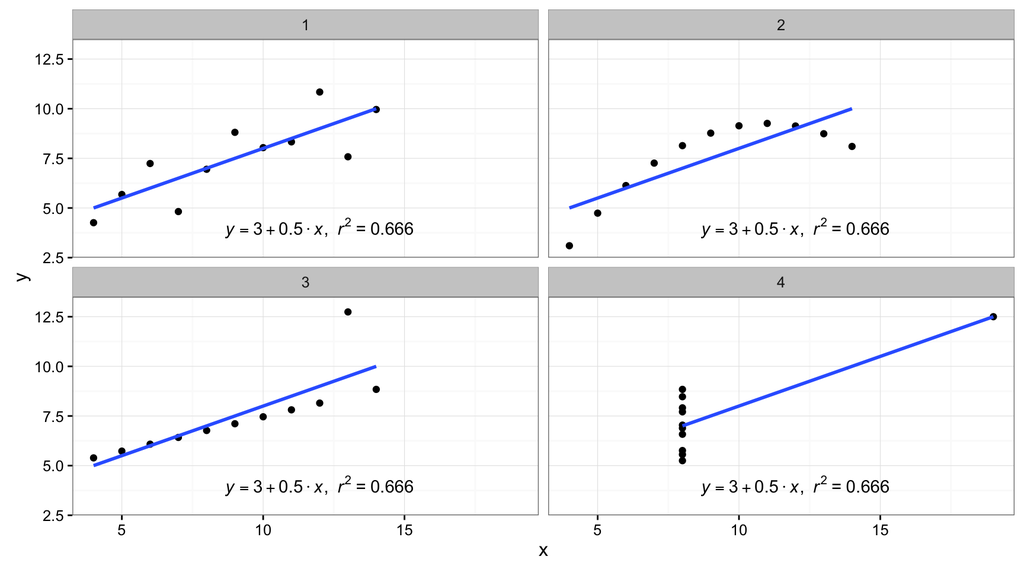

- What have you learned from visualizing the data?

## The raw Anscombe’s Quartet data

Data is in pairs (`x1` goes with `y1`, `x2` goes with `y2`, etc.)

| x1 | y1 | x2 | y2 | x3 | y3 | x4 | y4 |
| --- | --- | --- | --- | --- | --- | --- | --- |
| 10 | 8.04 | 10 | 9.14 | 10 | 7.46 | 8 | 6.58 |
| 8 | 6.95 | 8 | 8.14 | 8 | 6.77 | 8 | 5.76 |
| 13 | 7.58 | 13 | 8.74 | 13 | 12.74 | 8 | 7.71 |
| 9 | 8.81 | 9 | 8.77 | 9 | 7.11 | 8 | 8.84 |
| 11 | 8.33 | 11 | 9.26 | 11 | 7.81 | 8 | 8.47 |
| 14 | 9.96 | 14 | 8.10 | 14 | 8.84 | 8 | 7.04 |
| 6 | 7.24 | 6 | 6.13 | 6 | 6.08 | 8 | 5.25 |
| 4 | 4.26 | 4 | 3.10 | 4 | 5.39 | 19 | 12.50 |
| 12 | 10.84 | 12 | 9.13 | 12 | 8.15 | 8 | 5.56 |
| 7 | 4.82 | 7 | 7.26 | 7 | 6.42 | 8 | 7.91 |
| 5 | 5.68 | 5 | 4.74 | 5 | 5.73 | 8 | 6.89 |

# Visualizations: The Bad

### What’s wrong?

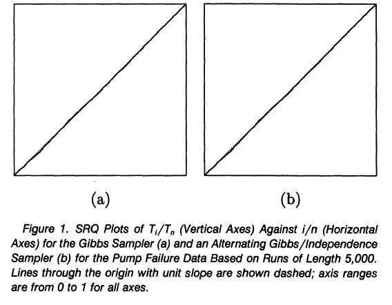

### What’s wrong?

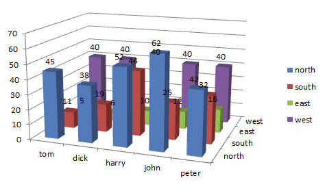

2015 State of the Union Twitter heat map for Lower 48 US

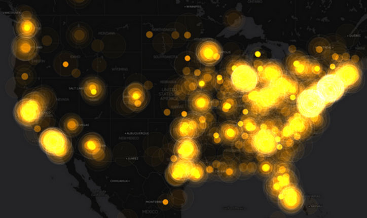

Source: [Glamour News](http://www.glamour.com/inspired/blogs/the-conversation/2015/01/the-hottest-twitter-topics-dur)

2010 Population Distribution in the US and Puerto Rico

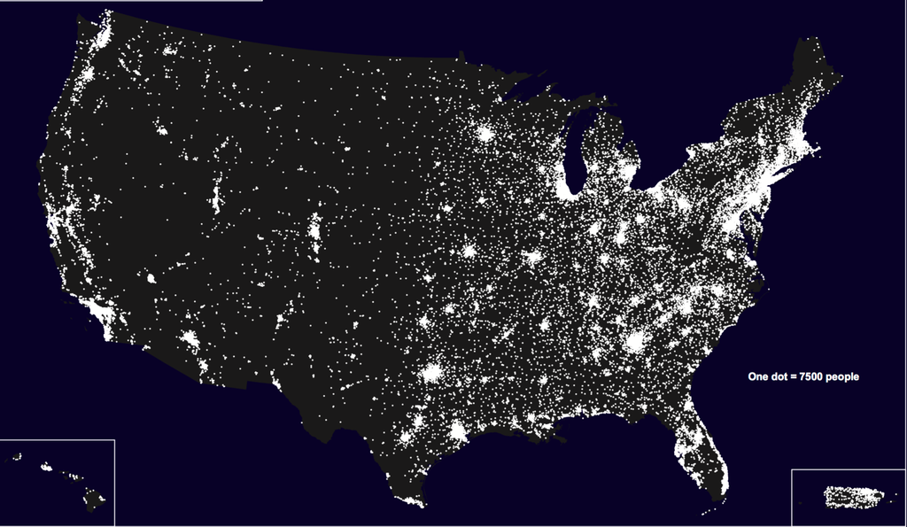

Source: [Census.gov](http://www2.census.gov/geo/maps/dc10_thematic/2010_Nighttime_PopDist/2010_Nighttime_PopDist_Page_Map.pdf)

# The Misleading

[figure not shown]

# Common plots and their uses

## Hopefully, The Good

## REVIEW: Variable types

- Quantitative (Numeric)
  - It is sensible to add, subtract, or take averages of the data values
  - *Continuous* - numerical values in a range (fractions and decimals included)
  - *Discrete* - numerical values with jumps (usually counts)
- Qualitative (Categorical)
  - Values designated by different groupings/categories (usually not numeric)

# How plots can assist with INFERENTIAL STATISTICS

[figure not shown]

## Setting up the hypotheses

- What’s the null hypothesis ($H_0$)?
  - The population mean `leniency` score is the same for `smile` versus `neutral` faces
  - $H_0: \mu_s = \mu_n$ or $H_0: \mu_s - \mu_n = 0$
- What’s the alternative hypothesis ($H_a$)?
  - The average `leniency` score is higher for smiling students than it is for students with a neutral facial expression.
  - $H_a: \mu_s > \mu_n$ or $H_a: \mu_s - \mu_n > 0$

### Side-by-side Histograms

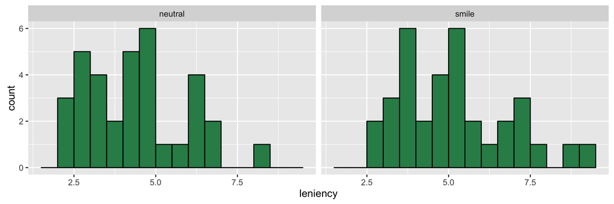

- One continuous variable versus one categorical variable
- Shows how many values are in different bins
- Questions to ask:
  - What is the shape? (Symmetric, skewed, etc.)
  - How many peaks are there? (Unimodal, bimodal, etc.)
  - How do the values *vary*?

### Side-by-side Boxplots

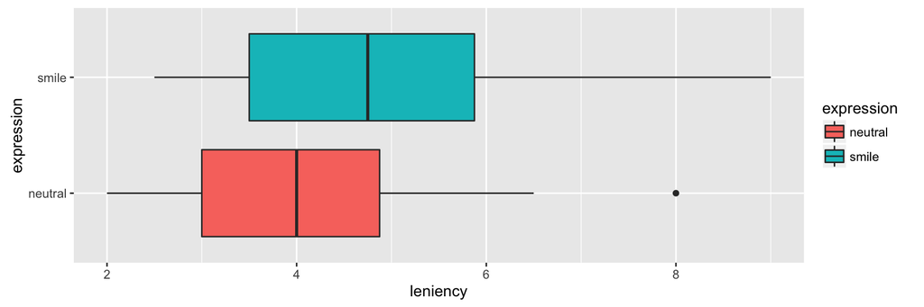

- One continuous variable versus one categorical variable
- Vertical bars represent quantiles
- Dots represent outliers

### Do we have reason to believe, based on the distributions of `leniency` scores over these two `expression` groups, that there is a significant *increase* in the mean leniency score for faces that `smile` compared to `neutral` faces?

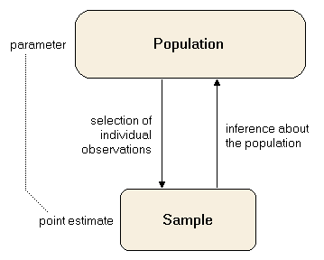

Source: [Statistics4u.info](http://www.statistics4u.info/fundstat_eng/img/sample_population.png)

## For the Smile Leniency problem

| expression | count | mean | sd |
| --- | --- | --- | --- |
| neutral | 34 | 4.117647 | 1.522850 |
| smile | 34 | 4.911765 | 1.680866 |

- What’s the sample?
  - The 68 student pictures showing either smiling or neutral expressions
- What’s the population?
  - Ideally, **ALL** students with either smiling or neutral expressions assigned punishment after an infraction
- We see that the sample mean leniency for those smiling, $\bar{x}_s$, is greater than the similar measure for those with neutral faces, $\bar{x}_n$.
- But is it statistically significantly greater?

### Assuming the null hypothesis is true…

- Recall that we have $H_0: \mu_s - \mu_n = 0$. What does this mean in laymen’s terms?
  - We are assuming that there is no relationship in `leniency` score and type of facial `expression`.
- We want to see if the difference in sample means could be explained by chance or if it is highly unlikely that chance is a good explanation for seeing a difference of that magnitude or larger.

### The Chance Process

- We can use a tactile point of view to explain what “chance” means here:
  - Use $n_n = 34$ blue index cards corresponding to `neutral` faces and $n_s = 34$ red index cards corresponding to faces that `smile`. What’s next?
  - Write the values of the corresponding `leniency` score on each of the index cards. What’s next?
  - Put the two stacks of index cards together, creating a new set of 68 cards.

### The Chance Process (continued)

- We can use the index cards to create two new stacks for those smiling and those with neutral faces.
  - First, we must shuffle all the cards thoroughly.
  - After doing so, in this case with equal values of sample sizes, we split the deck in half.
  - We then calculate the new sample mean leniency score of the smiling deck, and also the new sample mean leniency score of the neutral deck.
  - This creates one simulation of the samples.
  - We next want to calculate a statistic from these two samples.

### The Chance Process (continued again)

- We could do this actual shuffling and calculating, but it’s simpler to let the computer do mundane tasks.
- Recall that the original sample mean difference is $4.9117647 - 4.1176471 = 0.7941176$.
- From our simulation we obtain a difference of $-0.4117647$.
- What do we do next?
  - *More simulations!* Repeat this shuffling process, say, 10,000 times and then look at the distribution of the resulting sample mean differences.

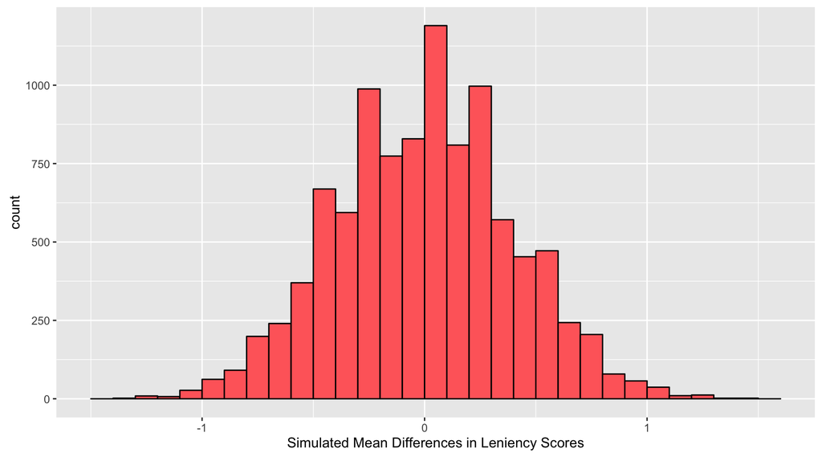

- What’s next?

### The p-value!

- Identify how many simulated mean differences are as extreme or more extreme as what we witnessed in our original sample mean difference.
  - Here this value is 0.0244.
- So only 2.44% of the simulated values are at or greater than what we saw with our original sample. Do we have evidence to reject $H_0: \mu_s - \mu_n = 0$ in favor of $H_a: \mu_s > \mu_n$?
  - Yes, our $p$-value of 0.0244 is a small proportion so we have little evidence in favor of the null hypothesis.

### The p-value Visualized

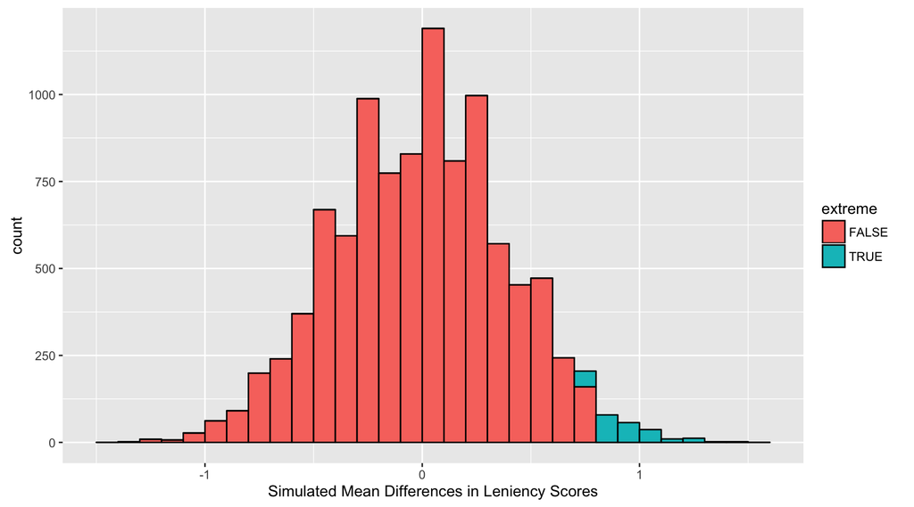

# But I thought this was a $t$-test problem?

- For the $t$-test, the test statistic is $t = \dfrac{\bar{x}_s - \bar{x}_n}{\sqrt{\dfrac{{s_s}^2}{n_s} + \dfrac{{s_n}^2}{n_n}}}$.
- So if we divided all of our simulated statistics by ${\sqrt{\frac{{s_s}^2}{n_s} + \frac{{s_n}^2}{n_n}}}$, we would be on the same scale as the $t$.
- What would the histogram of transformed values and corresponding $t$ curve look like plotted together?

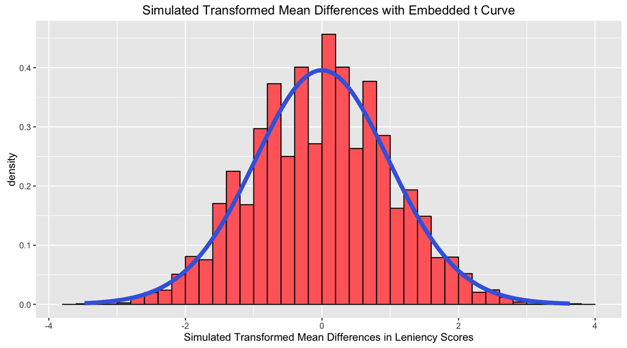

### Results of `t.test`

```
##
##  Welch Two Sample t-test
##
## data:  leniency by expression
## t = 2.0415, df = 65.367, p-value = 0.02262
## alternative hypothesis: true difference in means is greater than 0
## 95 percent confidence interval:
##  0.1451043       Inf
## sample estimates:
##   mean in group smile mean in group neutral
##              4.911765              4.117647
```

### Tying it together

- The $t$ distribution and also the normal distribution were developed to approximate the “by chance” distribution.
- When they were developed, scientists/statisticians couldn’t replicate the simulation 10,000 times like I have here.
- That’s why the `t.test` comes with lots of assumptions:
  - Sample sizes must be larger than 30
  - If sample sizes are not large enough, we need to assume the population distributions are normal.
    - That’s a BIG assumption!

# Another example of INFERENTIAL STATISTICS and Plotting

## Does spending extra time with non-academic activities hinder academic performance?

### Scatterplots

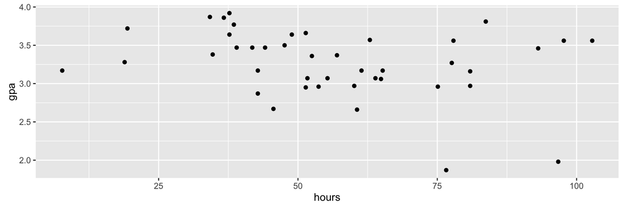

- Two continuous variables
- Questions to ask:
  - *Pattern* - Positive/No/Negative relation
  - *Form* - Linear/Non-linear
  - *Strength* - Closely matches fitted line?

## How was this “line of best fit” obtained?

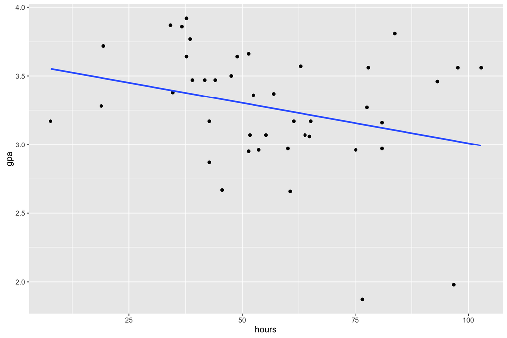

## Least squares estimation

- Given paired data $(x_1, y_1)$, $(x_2, y_2)$, $\cdots$, $(x_n, y_n)$, we model via the equation $y_j = \beta_0 + \beta_1 x_j + \varepsilon_j$.
- We want to minimize the sum of squared error terms ($\varepsilon_j$). Solving for $\varepsilon_j$, we minimize (using partial derivatives from calculus)
  $$\sum_{j=1}^n (y_j - \beta_0 - \beta_1 x_j)^2.$$

## Statistical software to the rescue!

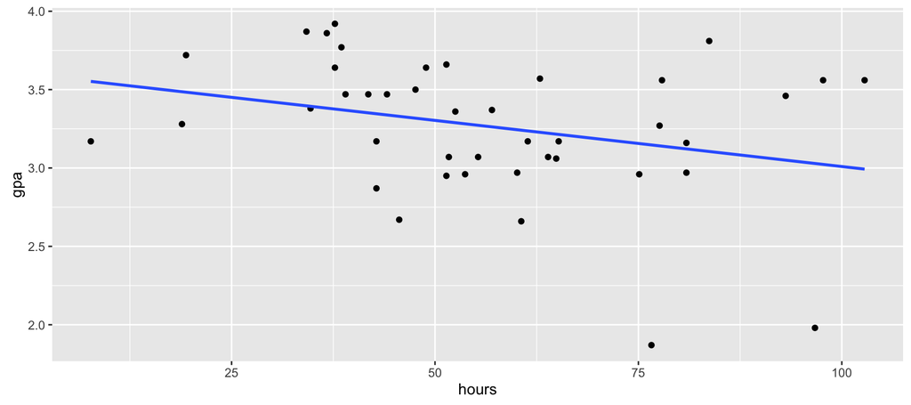

The equation of the fitted line is

$$\hat{gpa} = 3.598 -0.006 \times hours$$

## So…Is `hours` doing non-academic things a SIGNIFICANT NEGATIVE predictor of `gpa`?

- $H_0 : \beta_1 = 0$ versus $H_a: \beta_1 < 0$
- Our sample slope is -0.006. Is this far enough from zero to conclude that this observed slope is significant?
- We can do the same sort of resampling here by shuffling all of the response variable values and assigning them to each of the values of the explanatory variable.

## More shuffling!

- We assume that `hours` and `gpa` are not related.
- Any $x$ value could match up with any $y$ value.
- We shuffle the values of `gpa` and assign them to values of `hours`.
- We calculate the simulated slope statistic.
- We then repeat this process, say, 20,000 times and then see where our observed slope statistic $\hat{\beta}_1$ falls on that distribution.

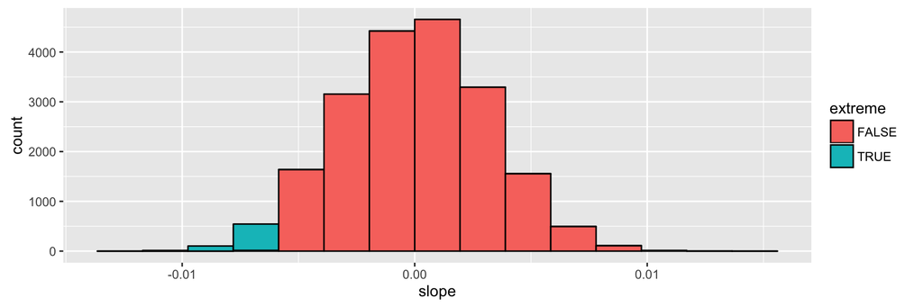

- The $p$-value is 0.0323 so we reject the null hypothesis.
- Based on this sample of university students, we have evidence to conclude that `hours` doing non-academic things is a significant negative predictor of `gpa`.
- A similar transformation shows that these results can be well-approximated by a $t$ distribution.

# Data Visualization Examples on the Web

## Links

- [Where Are the Hardest Places to Live in the U.S.?](http://www.nytimes.com/2014/06/26/upshot/where-are-the-hardest-places-to-live-in-the-us.html?_r=0)
- [Think with Google - Travel Trends](https://www.thinkwithgoogle.com/category-trends/travel-air-q4-2015.html#utm_source=Twitter&utm_medium=social&utm_campaign=Think)
- [Palo Alto Maintenance Requests](http://data.cityofpaloalto.org/dashboards/8677/paloalto311-requests-by-type/)
- [The Science of Social Timing](https://blog.kissmetrics.com/science-of-social-timing-1/)
- [Data Visualization Catalogue](http://www.datavizcatalogue.com/)
- [Why Most Twitter Maps Can’t Be Trusted](http://www.citylab.com/housing/2015/03/why-most-twitter-maps-cant-be-trusted/388586/)
- [Social Explorer](http://www.socialexplorer.com)

## What can I help you with?

- Data analysis
- Data wrangling/cleaning
- Data visualization
- Data tidying/manipulating
- Reproducible research

## When am I available?

- Email me at cismay@reed.edu or chester.ismay@reed.edu
- Tentative Spring 2016 office (ETC 223) hours
  - Mondays (10 AM to 11 AM)
  - Tuesdays (2 PM to 3 PM)
  - Wednesdays (1:30 PM to 2:30 PM)
  - Fridays (1:30 PM to 2:30 PM)
- Sometimes available for virtual office hours via Google Hangouts (email me for details)

# Thanks!

## cismay@reed.edu

Slides available at http://rpubs.com/cismay/ja_2016

Code for slide creation on [my GitHub page](https://github.com/ismayc/Reed_WoRkshops/tree/master/january_academy_2016)